# Experiment 1 Exploratory Spline Model Final Fifty

Dave Braun

7/21/2019

*This document was last updated at 2020-01-15 15:21:39.*

This document is dedicated to fitting a regression to model the choice data instead of using an ANOVA.

Redoing the analysis except only on the final 50 trials from each block.

```r
d <- read.csv('../../../../data/dstClean.csv')
N <- d %>%
  group_by(subject) %>%
  summarize(n()) %>%
  nrow()
head(d)
```

|  | subject | meancuedRt | sdcuedRt | meanChoiceRt | sdChoiceRt | windowWidth | redTask | screenHeight | blueTask | curTime | windowHeight | phase | userAgent | screenWidth | phaseRunTime | blockTime | cycle | cuedRt | difficulty | leftDeckSwitch | condition | chosenDeckId | rightDeckId | rightDeckSwitch | experimentRunTimeMins | choiceResponseKey | stimColor | cuedResponseKey | difference | … |
| --- | --- | --- | --- | --- | --- | --- | --- | --- | --- | --- | --- | --- | --- | --- | --- | --- | --- | --- | --- | --- | --- | --- | --- | --- | --- | --- | --- | --- | --- | --- |
| 1 | 1 | 997.9382 | 861.9834 | 357.5006 | 779.8603 | 1490 | mag | 864 | par | 21/07/2019@14:21:38 | 758 | dst | Mozilla/5.0 (Windows NT 10.0; Win64; x64) AppleWebKit/537.36 (KHTML, like Gecko) Chrome/75.0.3770.142 Safari/537.36 | 1536 | 2021817 | 118.518 | 1 | 427 | Easier than Reference | 0.1 | 0.1 | EE | reference | 0.5 | 11 | D | blue | K | Extreme | … |
| 2 | 1 | 997.9382 | 861.9834 | 357.5006 | 779.8603 | 1490 | mag | 864 | par | 21/07/2019@14:21:38 | 758 | dst | Mozilla/5.0 (Windows NT 10.0; Win64; x64) AppleWebKit/537.36 (KHTML, like Gecko) Chrome/75.0.3770.142 Safari/537.36 | 1536 | 2021817 | 118.518 | 1 | 555 | Easier than Reference | 0.1 | 0.1 | EE | reference | 0.5 | 11 | D | blue | K | Extreme | … |
| 3 | 1 | 997.9382 | 861.9834 | 357.5006 | 779.8603 | 1490 | mag | 864 | par | 21/07/2019@14:21:38 | 758 | dst | Mozilla/5.0 (Windows NT 10.0; Win64; x64) AppleWebKit/537.36 (KHTML, like Gecko) Chrome/75.0.3770.142 Safari/537.36 | 1536 | 2021817 | 118.518 | 1 | 471 | Easier than Reference | 0.1 | 0.1 | EE | reference | 0.5 | 11 | D | blue | K | Extreme | … |
| 4 | 1 | 997.9382 | 861.9834 | 357.5006 | 779.8603 | 1490 | mag | 864 | par | 21/07/2019@14:21:38 | 758 | dst | Mozilla/5.0 (Windows NT 10.0; Win64; x64) AppleWebKit/537.36 (KHTML, like Gecko) Chrome/75.0.3770.142 Safari/537.36 | 1536 | 2021817 | 118.518 | 1 | 1095 | Easier than Reference | 0.1 | 0.1 | EE | reference | 0.5 | 11 | D | blue | K | Extreme | … |
| 5 | 1 | 997.9382 | 861.9834 | 357.5006 | 779.8603 | 1490 | mag | 864 | par | 21/07/2019@14:21:38 | 758 | dst | Mozilla/5.0 (Windows NT 10.0; Win64; x64) AppleWebKit/537.36 (KHTML, like Gecko) Chrome/75.0.3770.142 Safari/537.36 | 1536 | 2021817 | 118.518 | 1 | 755 | Easier than Reference | 0.1 | 0.1 | EE | reference | 0.5 | 11 | D | blue | J | Extreme | … |
| 6 | 1 | 997.9382 | 861.9834 | 357.5006 | 779.8603 | 1490 | mag | 864 | par | 21/07/2019@14:21:38 | 758 | dst | Mozilla/5.0 (Windows NT 10.0; Win64; x64) AppleWebKit/537.36 (KHTML, like Gecko) Chrome/75.0.3770.142 Safari/537.36 | 1536 | 2021817 | 118.518 | 1 | 427 | Easier than Reference | 0.1 | 0.1 | EE | reference | 0.5 | 11 | D | blue | J | Extreme | … |

```r
## CRITICAL LINE
d <- d[d$trial >= 50,]
```

## Basic Regression

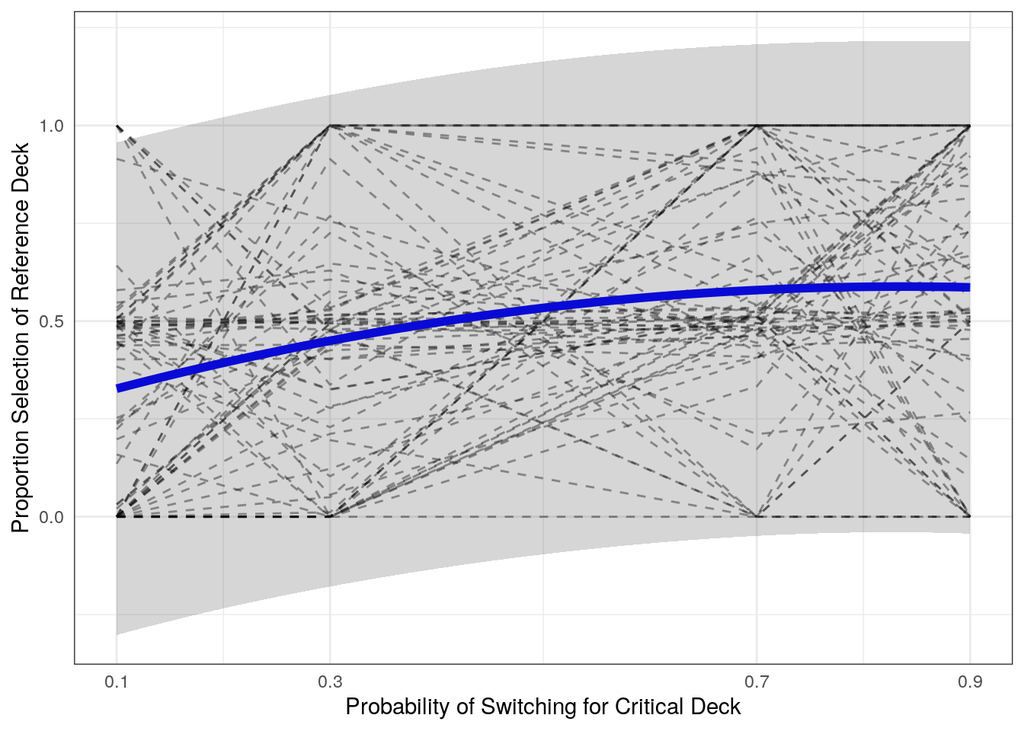

```r
test <- d %>%
  group_by(subject, condition) %>%
  summarize(srd = mean(srd)) %>%
  mutate(condition2 = condition^2)

m1 <- lm(srd ~ condition + condition2, data = test)

newdata <- data.frame(condition = seq(.1,.9,.01))
newdata$condition2 <- newdata$condition^2
newdata <- cbind(newdata, predict(m1, interval = 'predict', newdata = newdata))

newdata %>%
  ggplot(aes(x = condition, y = fit)) +
  geom_line(data = test, aes(x = condition, y = srd, group = subject), linetype = 'dashed', alpha = .4) +
  geom_line(size = 2, color = 'blue') +
  geom_ribbon(aes(ymin = lwr, ymax = upr), alpha = .2) +
  #ylim(-.5,1) +
  labs(
    x = 'Probability of Switching for Critical Deck',
    y = 'Proportion Selection of Reference Deck'
  ) +
  scale_x_continuous(breaks = c(.1,.3,.7,.9), labels = c(.1,.3,.7,.9)) +
  theme_bw() +
  theme(axis.ticks = element_blank())
```

```r
summary(m1)
```

```
##
## Call:
## lm(formula = srd ~ condition + condition2, data = test)
##
## Residuals:
##      Min       1Q   Median       3Q      Max
## -0.58628 -0.22514 -0.01332  0.19523  0.67269
##
## Coefficients:
##             Estimate Std. Error t value Pr(>|t|)
## (Intercept)  0.25165    0.05929   4.244 2.99e-05 ***
## condition    0.80470    0.32211   2.498   0.0131 *
## condition2  -0.48099    0.31647  -1.520   0.1297
## ---
## Signif. codes:  0 '***' 0.001 '**' 0.01 '*' 0.05 '.' 0.1 ' ' 1
##
## Residual standard error: 0.3177 on 277 degrees of freedom
## Multiple R-squared:  0.1017, Adjusted R-squared:  0.09526
## F-statistic: 15.69 on 2 and 277 DF,  p-value: 3.516e-07
```

This approach, in addition to being coarse, doesn’t do anything to test the prospect hypothesis.

## Baseline Spline Model

The general form and approach to the spline model is as follows:

$$\hat{Y} = \beta_0 + \beta_1X_1 + D_1\beta_{21}X_1^2 + D_2\beta_{22}X_1^2$$

Where $\hat{Y}$ is the binary response, $\beta_0$ and $\beta_1$ are the intercept and linear slope, respectively, $X_1$ is condition (ie, probability of switching for critical deck), $\beta_{21}$ and $\beta_{22}$ are the non-linear parameters, the $D$s represent dummy-coded variables that will ‘activate’ either non-linear component of the formula depending on an arbitrary criterion on $X_1$. The idea is that this model allows to test between the four different hypotheses using only one formulation, and the winning hypothesis should be clear based on the significance and sign of the coefficients.

```r
d$condition_c <- d$condition - 0.5
d$condition_c2 <- d$condition_c^2
d$dummy_pos <- ifelse(d$condition_c > 0, 1, 0)
d$dummy_neg <- ifelse(d$condition_c <= 0, 1, 0)

m2 <- lm(srd ~ condition_c + condition_c2:dummy_pos + condition_c2:dummy_neg, data = d)
summary(m2)
```

```
##
## Call:
## lm(formula = srd ~ condition_c + condition_c2:dummy_pos + condition_c2:dummy_neg,
##     data = d)
##
## Residuals:
##     Min      1Q  Median      3Q     Max
## -0.5844 -0.4429 -0.3218  0.4198  0.6782
##
## Coefficients:
##                         Estimate Std. Error t value Pr(>|t|)
## (Intercept)             0.531048   0.006002  88.476  < 2e-16 ***
## condition_c             0.358317   0.045016   7.960 1.80e-15 ***
## condition_c2:dummy_pos -0.562202   0.133144  -4.223 2.42e-05 ***
## condition_c2:dummy_neg -0.411987   0.131884  -3.124  0.00179 **
## ---
## Signif. codes:  0 '***' 0.001 '**' 0.01 '*' 0.05 '.' 0.1 ' ' 1
##
## Residual standard error: 0.4876 on 24900 degrees of freedom
## Multiple R-squared:  0.04772,    Adjusted R-squared:  0.0476
## F-statistic: 415.9 on 3 and 24900 DF,  p-value: < 2.2e-16
```

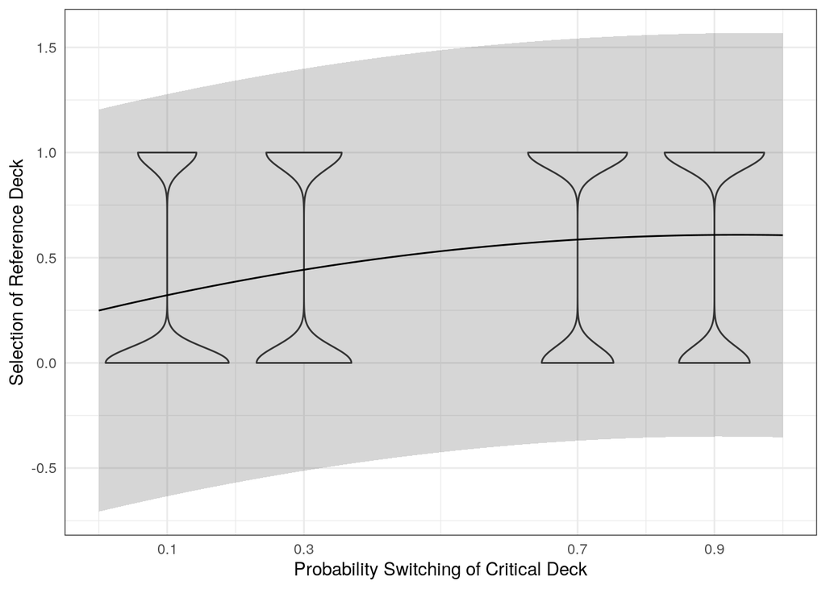

```r
newdata <- data.frame(condition_c = seq(-.5,.5,.01))
newdata$condition_c2 <- newdata$condition_c^2
newdata$dummy_pos <- ifelse(newdata$condition_c > .5, 1, 0)
newdata$dummy_neg <- ifelse(newdata$condition_c <= .5, 1, 0)
newdata$condition <- seq(0,1,.01)
newdata$condition2 <- newdata$condition^2
newdata <- cbind(newdata, predict(m2, newdata = newdata, interval = 'predict'))


newdata %>%
  ggplot(aes(x = condition, y = fit)) +
  #geom_jitter(data = d, aes(x = condition, y = srd), height = 0, alpha = .2) +
  geom_violin(data = d, aes(x = condition, y = srd, group = condition)) +
  geom_ribbon(aes(ymin = lwr, ymax = upr), alpha = .2)+
  geom_line() +
  labs(
    x = 'Probability Switching of Critical Deck',
    y = 'Selection of Reference Deck'
  ) +
  scale_x_continuous(breaks = c(.1,.3,.7,.9), labels = c(.1,.3,.7,.9)) +
  theme_bw() +
  theme(axis.ticks = element_blank())
```

## Spline Model with Logit Link

```r
m3 <- glm(srd ~ condition_c + dummy_pos:condition_c2 + dummy_neg:condition_c2, data = d, family = binomial(link = 'logit'))

newdata <- data.frame(condition_c = seq(-.5,.5,.01))
newdata$condition_c2 <- newdata$condition_c^2
newdata$dummy_pos <- ifelse(newdata$condition_c > .5, 1, 0)
newdata$dummy_neg <- ifelse(newdata$condition_c <= .5, 1, 0)
newdata$condition <- seq(0,1,.01)
newdata$condition2 <- newdata$condition^2
newdata <- cbind(newdata, data.frame(predict(m3, newdata = newdata, type = 'response', se.fit = TRUE)))

summary(m3)
```

```
##
## Call:
## glm(formula = srd ~ condition_c + dummy_pos:condition_c2 + dummy_neg:condition_c2,
##     family = binomial(link = "logit"), data = d)
##
## Deviance Residuals:
##     Min       1Q   Median       3Q      Max
## -1.3252  -1.0817  -0.8813   1.0434   1.5059
##
## Coefficients:
##                        Estimate Std. Error z value Pr(>|z|)
## (Intercept)             0.13030    0.02491   5.231 1.69e-07 ***
## condition_c             1.40728    0.18683   7.532 4.98e-14 ***
## dummy_pos:condition_c2 -2.20160    0.55326  -3.979 6.91e-05 ***
## condition_c2:dummy_neg -1.95550    0.55330  -3.534 0.000409 ***
## ---
## Signif. codes:  0 '***' 0.001 '**' 0.01 '*' 0.05 '.' 0.1 ' ' 1
##
## (Dispersion parameter for binomial family taken to be 1)
##
##     Null deviance: 34486  on 24903  degrees of freedom
## Residual deviance: 33279  on 24900  degrees of freedom
## AIC: 33287
##
## Number of Fisher Scoring iterations: 4
```

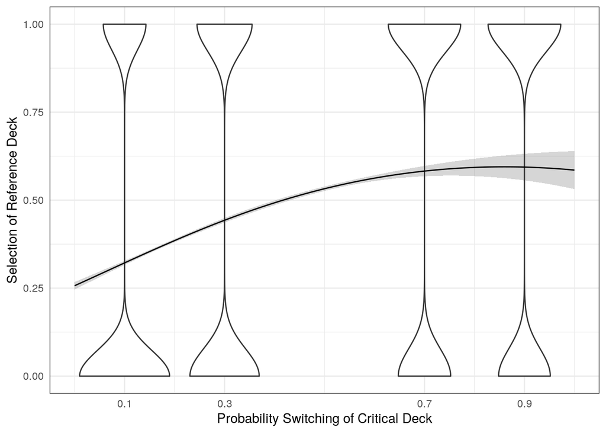

```r
newdata %>%
  ggplot(aes(x = condition, y = fit)) +
  #geom_jitter(data = d, aes(x = condition, y = srd), height = 0, alpha = .2) +
  geom_violin(data = d, aes(x = condition, y = srd, group = condition)) +
  geom_ribbon(aes(ymin = fit - se.fit, ymax = fit + se.fit), alpha = .2)+
  geom_line() +
  labs(
    x = 'Probability Switching of Critical Deck',
    y = 'Selection of Reference Deck'
  ) +
  scale_x_continuous(breaks = c(.1,.3,.7,.9), labels = c(.1,.3,.7,.9)) +
  theme_bw() +
  theme(axis.ticks = element_blank())
```

Yea, I like where this is going.

## Spline Model with Logit Link and Random Effects

Let the games begin.

I think all I’ll do ahead of model fitting is just visualize some descriptive intercept variability.

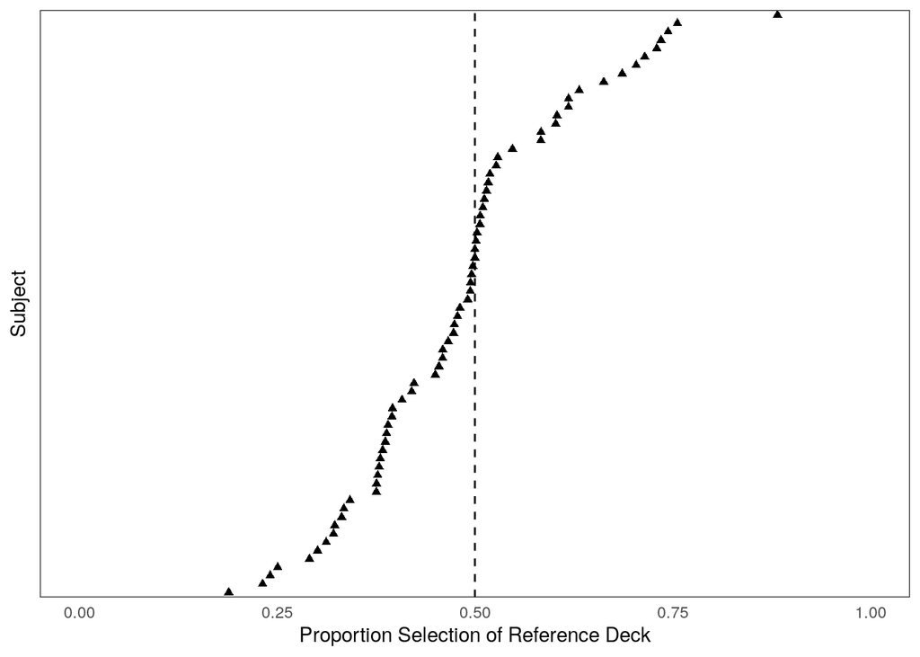

```r
d %>%
  group_by(subject) %>%
  summarize(srd = mean(srd)) %>%
  ggplot(aes(x = reorder(subject, srd), y = srd)) +
  geom_point(shape = 17) +
  geom_hline(yintercept = .5, linetype = 'dashed') +
  labs(
    x = 'Subject',
    y = 'Proportion Selection of Reference Deck'
  ) +
  ylim(0,1) +
  theme_bw() +
  theme(axis.ticks = element_blank(),
        axis.text.y = element_blank(),
        panel.grid = element_blank()) +
  coord_flip()
```

### Model fits

```r
## failed to converge
# m_max <- glmer(srd ~ condition_c + dummy_pos:condition_c2 + dummy_neg:condition_c2 +
#                  (1 + condition_c + dummy_pos:condition_c2 + dummy_neg:condition_c2 | subject),
#                data = d, family = binomial(link = 'logit'), control = glmerControl(optimizer = 'bobyqa'), nAGQ = 1)

m_1 <- glmer(srd ~ condition_c + dummy_pos:condition_c2 + dummy_neg:condition_c2 +
                 (1 + condition_c + dummy_pos:condition_c2 | subject) +
                 (0 + dummy_neg:condition_c2 | subject),
               data = d, family = binomial(link = 'logit'), control = glmerControl(optimizer = 'bobyqa'), nAGQ = 1)

m_2 <- glmer(srd ~ condition_c + dummy_pos:condition_c2 + dummy_neg:condition_c2 +
              (1 + condition_c | subject) +
              (0 + dummy_neg:condition_c2 | subject) +
              (0 + dummy_pos:condition_c2 | subject),
               data = d, family = binomial(link = 'logit'), control = glmerControl(optimizer = 'bobyqa'), nAGQ = 1)

save(m_1, m_2, file = 'glmer_models.RData')
```

```r
load('glmer_models.RData')

anova(m_1, m_2)
```

|  | Df | AIC | BIC | logLik | deviance | Chisq | Chi Df | Pr(>Chisq) |
| --- | --- | --- | --- | --- | --- | --- | --- | --- |
| m_2 | 9 | 21280.4 | 21353.50 | -10631.20 | 21262.4 | NA | NA | NA |
| m_1 | 11 | 21222.7 | 21312.05 | -10600.35 | 21200.7 | 61.7014 | 2 | 3.99678e-14 |

Even though it was a two-parameter step down (because I’m not sure how to specify only dropping one covariance), I’ll take the more complex model as the best fitting.

### Diagnostics and Model Summaries

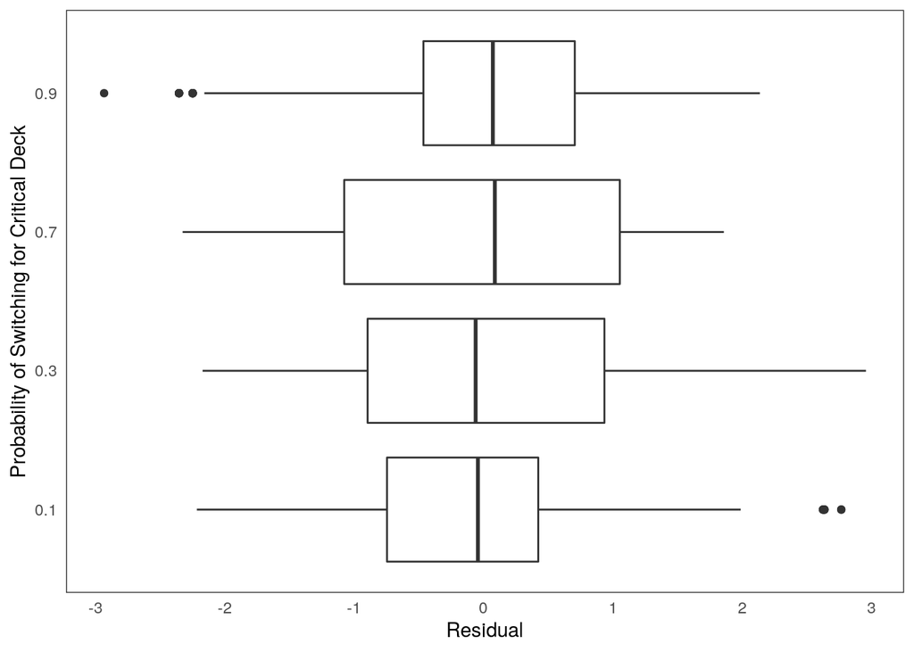

```r
d$resid <- resid(m_1)

d %>%
  ggplot(aes(x = factor(condition), y = resid)) +
  geom_boxplot() +
  labs(
    x = 'Probability of Switching for Critical Deck',
    y = 'Residual'
  ) +
  scale_x_discrete(breaks = c(.1, .3, .7, .9), labels = c(.1, .3, .7, .9)) +
  theme_bw() +
  theme(axis.ticks = element_blank(),
        panel.grid = element_blank()) +
  coord_flip()
```

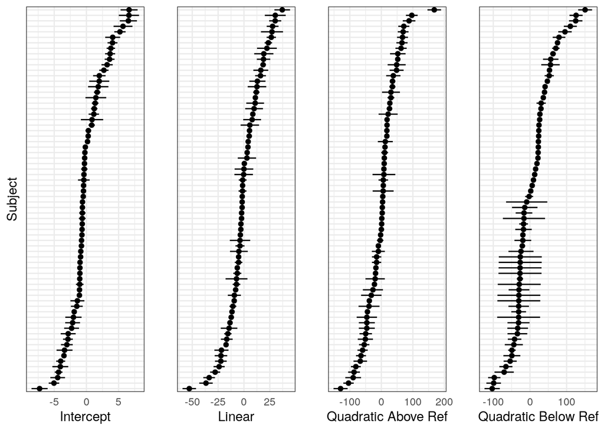

```r
rans <- data.frame(ranef(m_1, condVar = TRUE))

p1 <- rans %>%
  filter(term == '(Intercept)') %>%
  ggplot(aes(x = reorder(grp, condval), y = condval)) +
  geom_errorbar(aes(ymin = condval - condsd, ymax = condval + condsd), width = 0) +
  geom_point() +
  labs(
    x = 'Subject',
    y = 'Intercept'
  ) +
  theme_bw() +
  theme(axis.ticks = element_blank(),
        axis.text.y = element_blank()) +
  coord_flip()

p2 <- rans %>%
  filter(term == 'condition_c') %>%
  ggplot(aes(x = reorder(grp, condval), y = condval)) +
  geom_errorbar(aes(ymin = condval - condsd, ymax = condval + condsd), width = 0) +
  geom_point() +
  labs(
    x = '',
    y = 'Linear'
  ) +
  theme_bw() +
  theme(axis.ticks = element_blank(),
        axis.text.y = element_blank()) +
  coord_flip()

p3 <- rans %>%
  filter(term == 'dummy_pos:condition_c2') %>%
  ggplot(aes(x = reorder(grp, condval), y = condval)) +
  geom_errorbar(aes(ymin = condval - condsd, ymax = condval + condsd), width = 0) +
  geom_point() +
  labs(
    x = '',
    y = 'Quadratic Above Ref'
  ) +
  theme_bw() +
  theme(axis.ticks = element_blank(),
        axis.text.y = element_blank()) +
  coord_flip()

p4 <- rans %>%
  filter(term == 'dummy_neg:condition_c2') %>%
  ggplot(aes(x = reorder(grp, condval), y = condval)) +
  geom_errorbar(aes(ymin = condval - condsd, ymax = condval + condsd), width = 0) +
  geom_point() +
  labs(
    x = '',
    y = 'Quadratic Below Ref'
  ) +
  theme_bw() +
  theme(axis.ticks = element_blank(),
        axis.text.y = element_blank()) +
  coord_flip()

grid.arrange(p1,p2,p3,p4, nrow = 1)
```

## Inference

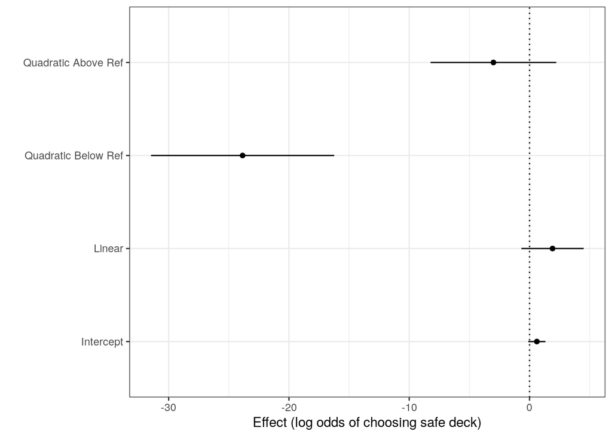

```r
## too expensive
#m1_CI_prof <- confint(m_1, maxpts = 8)
m1_CI_quad <- confint(m_1, method = 'Wald')
#m1_CI_boot <- confint(m_1, method = 'boot')
#
# CIs <- data.frame(m1_CI_prof)
# CIs$factor <- row.names(CIs)
# CIs$method <- 'prof'

t1 <- data.frame(m1_CI_quad)
t1$factor <- row.names(t1)
t1$method <- 'Wald'
CIs <- t1

# t2 <- data.frame(m1_CI_boot)
# t2$factor <- row.names(t2)
# t2$method <- 'boot'
#
# CIs <- rbind(CIs, t1, t2)

CIs <- CIs %>%
  filter(!grepl('.sig', factor))
colnames(CIs)[1:2] <- c('lower', 'upper')
CIs$estimate <- fixef(m_1)

#save(CIs, file = 'CIs.RData')

CIs %>%
  ggplot(aes(x = factor, y = estimate)) +
  geom_hline(yintercept = 0, linetype = 'dotted') +
  geom_errorbar(aes(ymin = lower, ymax = upper), width = 0) +
  geom_point() +
  coord_flip()+
  scale_x_discrete(labels = c(`(Intercept)` = 'Intercept', `condition_c` = 'Linear', `condition_c2:dummy_neg` = 'Quadratic Below Ref', `dummy_pos:condition_c2` = 'Quadratic Above Ref')) +
  labs(
    y = 'Effect (log odds of choosing safe deck)',
    x = ''
  ) +
  theme_bw()
```

## Hypothesis Testing

Via likelihood ratio tests:

```r
m_1_nolinear <- update(m_1, .~.-condition_c)
m_1_nonegquad <- update(m_1, .~.-dummy_neg:condition_c2, control = glmerControl(optimizer = 'bobyqa'))
m_1_noposquad <- update(m_1, .~.-dummy_pos:condition_c2)
m_1_noint <- glmer(srd ~ 0 + condition_c + dummy_pos:condition_c2 + dummy_neg:condition_c2 +
                 (1 + condition_c + dummy_pos:condition_c2 | subject) +
                 (0 + dummy_neg:condition_c2 | subject),
               data = d, family = binomial(link = 'logit'), control = glmerControl(optimizer = 'bobyqa'), nAGQ = 1)

save(m_1_nolinear, m_1_nonegquad, m_1_noposquad, m_1_noint, file = 'lrt_models.Rdata')
```

```r
load('lrt_models.Rdata')

## convert estimates to odds ratios
vc <- as.data.frame(VarCorr(m_1))
vc <- vc[is.na(vc$var2),]$sdcor
result <- exp(cbind(est = fixef(m_1), confint(m_1, parm = 'beta_', method = 'Wald')))
result <- cbind(data.frame(estLogOdds = fixef(m_1), sdLogOdds = vc), result)

chisq <- anova(m_1, m_1_noint)$Chisq[2]
p <- anova(m_1, m_1_noint)$`Pr(>Chisq)`[2]
chisq <- append(chisq, anova(m_1, m_1_nolinear)$Chisq[2])
p <- append(p, anova(m_1, m_1_nolinear)$`Pr(>Chisq)`[2])
chisq <- append(chisq, anova(m_1, m_1_noposquad)$Chisq[2])
p <- append(p, anova(m_1, m_1_noposquad)$`Pr(>Chisq)`[2])
chisq <- append(chisq, anova(m_1, m_1_nonegquad)$Chisq[2])
p <- append(p, anova(m_1, m_1_nonegquad)$`Pr(>Chisq)`[2])
waldp <- c(NA, car::Anova(m_1)$`Pr(>Chisq)`)

result <- cbind(result, data.frame(Wald = waldp, chisq = chisq, chisq_p = p))
colnames(result)[4:5] <- c('LwrCI', 'UprCI')
```

**Final result:**

```r
data.frame(result)
```

|  | estLogOdds | sdLogOdds | est | LwrCI | UprCI | Wald | chisq | chisq_p |
| --- | --- | --- | --- | --- | --- | --- | --- | --- |
| (Intercept) | 0.6067922 | 3.250137 | 1.834537e+00 | 8.991425e-01 | 3.743040e+00 | NA | 2.1870136 | 0.139178936 |
| condition_c | 1.9117529 | 19.375535 | 6.764937e+00 | 5.071608e-01 | 9.023641e+01 | 1.480859e-01 | 0.5359284 | 0.464125050 |
| dummy_pos:condition_c2 | -3.0024178 | 58.222202 | 4.966684e-02 | 2.672267e-04 | 9.231095e+00 | 2.600614e-01 | 0.1303965 | 0.718021297 |
| condition_c2:dummy_neg | -23.8532966 | 64.828920 | 4.371645e-11 | 2.155658e-14 | 8.865639e-08 | 8.274437e-10 | 7.7697121 | 0.005312952 |

## Prediction

```r
easyPredCI <- function(model,newdata=NULL,alpha=0.05) {
    ## baseline prediction, on the linear predictor (logit) scale:
    pred0 <- predict(model,re.form=NA,newdata=newdata)
    ## fixed-effects model matrix for new data
    X <- model.matrix(formula(model,fixed.only=TRUE)[-2],newdata)
    beta <- fixef(model) ## fixed-effects coefficients
    V <- vcov(model)     ## variance-covariance matrix of beta
    pred.se <- sqrt(diag(X %*% V %*% t(X))) ## std errors of predictions
    ## inverse-link function
    linkinv <- family(model)$linkinv
    ## construct 95% Normal CIs on the link scale and
    ##  transform back to the response (probability) scale:
    crit <- -qnorm(alpha/2)
    linkinv(cbind(conf.low=pred0-crit*pred.se,
                  conf.high=pred0+crit*pred.se))
}
```

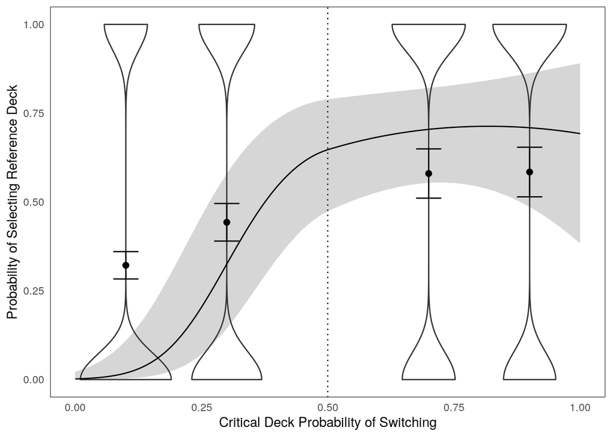

```r
newdata <- data.frame(condition_c = seq(-.5, .5, .01))
newdata$condition_c2 <- newdata$condition_c^2
newdata$dummy_neg <- ifelse(newdata$condition_c <= 0, 1, 0)
newdata$dummy_pos <- ifelse(newdata$condition_c > 0, 1, 0)

pred <- predict(m_1, re.form = NA, newdata = newdata, type = 'response')
pred.CI <- easyPredCI(m_1, newdata)

newdata <- cbind(newdata, data.frame(est = pred), pred.CI)

## get subject cell means
sm <- d %>%
  group_by(subject, condition) %>%
  summarize(srd = mean(srd))

## get condition means
cm <- d %>%
  group_by(condition) %>%
  summarize(obs = mean(srd), se = mean(srd) / sqrt(N))


newdata %>%
  mutate(condition = condition_c + 0.5) %>%
  ggplot(aes(x = condition, y = est)) +
    geom_vline(xintercept = 0.5, linetype = 'dotted') +
    #geom_line(data = sm, aes(x = condition, y = srd, group = subject), linetype = 'dashed', alpha = .1) +
    geom_violin(data = d, aes(x = condition, y = srd, group = condition)) +
    geom_ribbon(aes(ymin = conf.low, ymax = conf.high), alpha = .2) +
    geom_line() +
    geom_point(data = cm, aes(x = condition, y = obs), size = 2) +
    geom_errorbar(data = cm, aes(x = condition, ymin = obs - se, ymax = obs + se, y = obs), width = .05) +
    ylim(0,1) +
    labs(
      x = 'Critical Deck Probability of Switching',
      y = 'Probability of Selecting Reference Deck'
    ) +
    theme_bw() +
    theme(axis.ticks = element_blank(),
          panel.grid = element_blank())
```

With subject means:

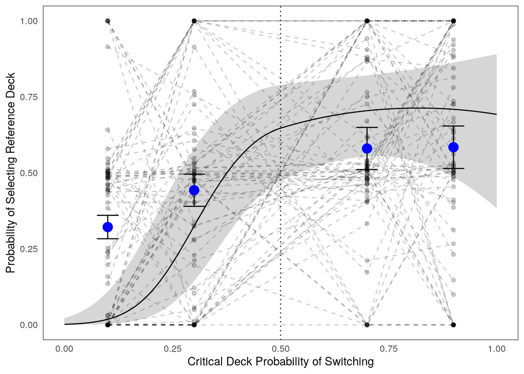

```r
newdata %>%
  mutate(condition = condition_c + 0.5) %>%
  ggplot(aes(x = condition, y = est)) +
    geom_vline(xintercept = 0.5, linetype = 'dotted') +
    geom_line(data = sm, aes(x = condition, y = srd, group = subject), linetype = 'dashed', alpha = .2) +
    geom_point(data = sm, aes(x = condition, y = srd, group = subject), alpha = .2) +
    #geom_violin(data = d, aes(x = condition, y = srd, group = condition)) +
    geom_ribbon(aes(ymin = conf.low, ymax = conf.high), alpha = .2) +
    geom_line() +
    geom_errorbar(data = cm, aes(x = condition, ymin = obs - se, ymax = obs + se, y = obs), width = .05) +
    geom_point(data = cm, aes(x = condition, y = obs), size = 4, color = 'blue') +
    ylim(0,1) +
    labs(
      x = 'Critical Deck Probability of Switching',
      y = 'Probability of Selecting Reference Deck'
    ) +
    theme_bw() +
    theme(axis.ticks = element_blank(),
          panel.grid = element_blank())
```

[Analysis Homepage](https://davebraun.net/dissertation/experiments/analysis/)

A work by [Dave Braun](https://davebraun.net)

*dab414@lehigh.edu*